# People Analytics Understanding Employee Performance and Retention

```python
import pandas as pd
import numpy as np
import matplotlib.pyplot as plt
import seaborn as sns
import warnings
warnings.filterwarnings("ignore", category=FutureWarning)
```

```python
employee_data = pd.read_csv('employee_data.csv')
```

```python
employee_data.head()
```

|  | EmpID | FirstName | LastName | StartDate | ExitDate | Title | Supervisor | ADEmail | BusinessUnit | EmployeeStatus | ... | Division | DOB | State | JobFunctionDescription | GenderCode | LocationCode | RaceDesc | MaritalDesc | Performance Score | Current Employee Rating |
| --- | --- | --- | --- | --- | --- | --- | --- | --- | --- | --- | --- | --- | --- | --- | --- | --- | --- | --- | --- | --- | --- |
| 0 | 3427 | Uriah | Bridges | 20-Sep-19 | NaN | Production Technician I | Peter Oneill | uriah.bridges@bilearner.com | CCDR | Active | ... | Finance & Accounting | 07-10-1969 | MA | Accounting | Female | 34904 | White | Widowed | Fully Meets | 4 |
| 1 | 3428 | Paula | Small | 11-Feb-23 | NaN | Production Technician I | Renee Mccormick | paula.small@bilearner.com | EW | Active | ... | Aerial | 30-08-1965 | MA | Labor | Male | 6593 | Hispanic | Widowed | Fully Meets | 3 |
| 2 | 3429 | Edward | Buck | 10-Dec-18 | NaN | Area Sales Manager | Crystal Walker | edward.buck@bilearner.com | PL | Active | ... | General - Sga | 06-10-1991 | MA | Assistant | Male | 2330 | Hispanic | Widowed | Fully Meets | 4 |
| 3 | 3430 | Michael | Riordan | 21-Jun-21 | NaN | Area Sales Manager | Rebekah Wright | michael.riordan@bilearner.com | CCDR | Active | ... | Finance & Accounting | 04-04-1998 | ND | Clerk | Male | 58782 | Other | Single | Fully Meets | 2 |
| 4 | 3431 | Jasmine | Onque | 29-Jun-19 | NaN | Area Sales Manager | Jason Kim | jasmine.onque@bilearner.com | TNS | Active | ... | General - Con | 29-08-1969 | FL | Laborer | Female | 33174 | Other | Married | Fully Meets | 3 |

5 rows × 26 columns

```python
employee_data.shape
```

```
(3000, 26)
```

```python
# Display basic dataset information
employee_data.isnull().sum()
```

```
EmpID                            0
FirstName                        0
LastName                         0
StartDate                        0
ExitDate                      1467
Title                            0
Supervisor                       0
ADEmail                          0
BusinessUnit                     0
EmployeeStatus                   0
EmployeeType                     0
PayZone                          0
EmployeeClassificationType       0
TerminationType                  0
TerminationDescription        1467
DepartmentType                   0
Division                         0
DOB                              0
State                            0
JobFunctionDescription           0
GenderCode                       0
LocationCode                     0
RaceDesc                         0
MaritalDesc                      0
Performance Score                0
Current Employee Rating          0
dtype: int64
```

```python
# Summary statistics for numeric columns
employee_data.describe()
```

|  | EmpID | LocationCode | Current Employee Rating |
| --- | --- | --- | --- |
| count | 3000.000000 | 3000.000000 | 3000.000000 |
| mean | 2500.500000 | 44997.180667 | 2.969000 |
| std | 866.169729 | 29987.331783 | 1.015078 |
| min | 1001.000000 | 1013.000000 | 1.000000 |
| 25% | 1750.750000 | 17546.000000 | 2.000000 |
| 50% | 2500.500000 | 44150.500000 | 3.000000 |
| 75% | 3250.250000 | 71481.250000 | 3.000000 |
| max | 4000.000000 | 98052.000000 | 5.000000 |

```python
# Check data types
employee_data.dtypes
```

```
EmpID                          int64
FirstName                     object
LastName                      object
StartDate                     object
ExitDate                      object
Title                         object
Supervisor                    object
ADEmail                       object
BusinessUnit                  object
EmployeeStatus                object
EmployeeType                  object
PayZone                       object
EmployeeClassificationType    object
TerminationType               object
TerminationDescription        object
DepartmentType                object
Division                      object
DOB                           object
State                         object
JobFunctionDescription        object
GenderCode                    object
LocationCode                   int64
RaceDesc                      object
MaritalDesc                   object
Performance Score             object
Current Employee Rating        int64
dtype: object
```

```python
# Check unique value counts
employee_data.nunique()
```

```
EmpID                         3000
FirstName                     1597
LastName                      1137
StartDate                     1496
ExitDate                       820
Title                           32
Supervisor                    2952
ADEmail                       2998
BusinessUnit                    10
EmployeeStatus                   5
EmployeeType                     3
PayZone                          3
EmployeeClassificationType       3
TerminationType                  5
TerminationDescription        1533
DepartmentType                   6
Division                        25
DOB                           2800
State                           28
JobFunctionDescription          83
GenderCode                       2
LocationCode                  2821
RaceDesc                         5
MaritalDesc                      4
Performance Score                4
Current Employee Rating          5
dtype: int64
```

### Distribution of Performance Scores

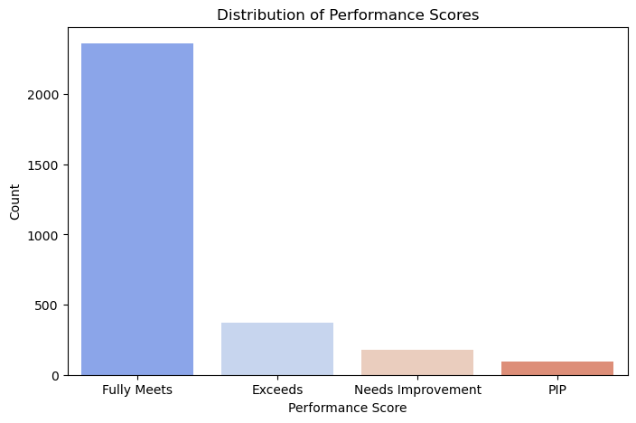

```python
# Distribution of Performance Scores
plt.figure(figsize=(8, 5))
sns.countplot(data=employee_data, x='Performance Score', palette='coolwarm')
plt.title("Distribution of Performance Scores")
plt.xlabel("Performance Score")
plt.ylabel("Count")
plt.show()
```

## Insights:

1. **High Performance Levels**:
   - The predominance of "Fully Meets" scores reflects a generally competent and effective workforce, suggesting strong hiring practices or effective management.
2. **Focus on Outliers**:
   - Efforts can be directed at employees with "Needs Improvement" or "PIP" scores through training, mentoring, or re-evaluating performance metrics to boost overall productivity.

### Employee Status Distribution

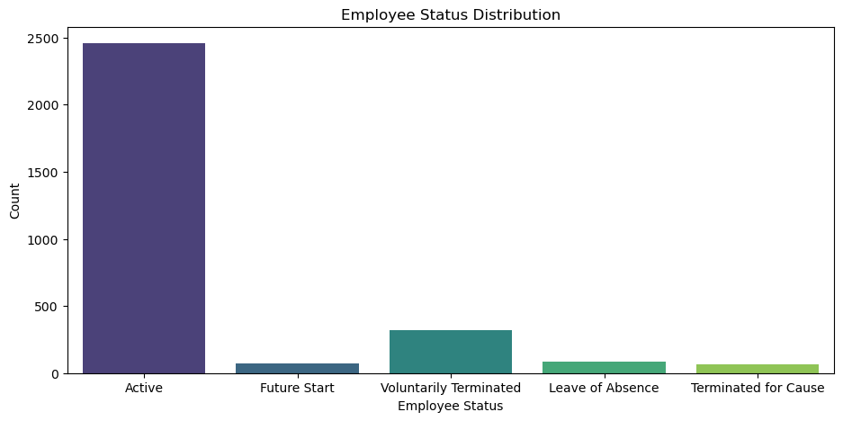

```python
# Employee status distribution
plt.figure(figsize=(11, 5))
sns.countplot(data=employee_data, x='EmployeeStatus', palette='viridis')
plt.title("Employee Status Distribution")
plt.xlabel("Employee Status")
plt.ylabel("Count")
plt.show()
```

## Findings:

1. **Majority Active**:
   - The majority of employees (~2,500) are in the "Active" category, significantly outweighing other statuses.
2. **Small Proportions**:
   - Other categories like "Voluntarily Terminated," "Leave of Absence," and "Terminated for Cause" have very small counts compared to the active workforce.

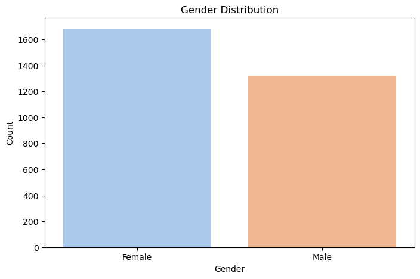

```python
# Gender distribution
plt.figure(figsize=(8, 5))
sns.countplot(data=employee_data, x='GenderCode', palette='pastel')
plt.title("Gender Distribution")
plt.xlabel("Gender")
plt.ylabel("Count")
plt.show()
```

## Insights:

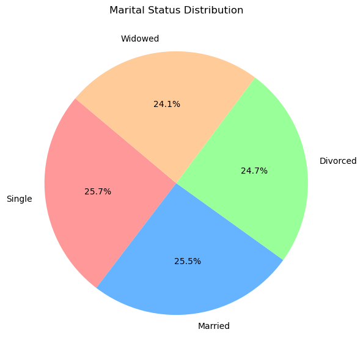

```python
# Count the occurrences of each marital status
marital_status_counts = employee_data['MaritalDesc'].value_counts()

# Plotting the pie chart with different colors
plt.figure(figsize=(7, 7))
colors = ['#ff9999', '#66b3ff', '#99ff99', '#ffcc99']  # Custom color palette
plt.pie(
    marital_status_counts,
    labels=marital_status_counts.index,
    autopct='%1.1f%%',
    startangle=140,
    colors=colors
)
plt.title("Marital Status Distribution")
plt.show()
```

## Findings:

1. **Even Distribution**:
   - The marital status categories (`Single`, `Married`, `Divorced`, `Widowed`) are nearly evenly distributed, with no significant dominance by any group.
2. **Largest Group**:
   - The `Single` category represents the largest group (25.7%), followed closely by `Married` (25.5%).

## Insights:

1. **Workplace Diversity**:
   - The balanced distribution suggests a diverse workforce in terms of marital status, which could be beneficial for workplace inclusivity.
2. **Policy Considerations**:
   - Policies related to benefits and work-life balance should cater to employees across all marital statuses, given the almost equal representation of each group.

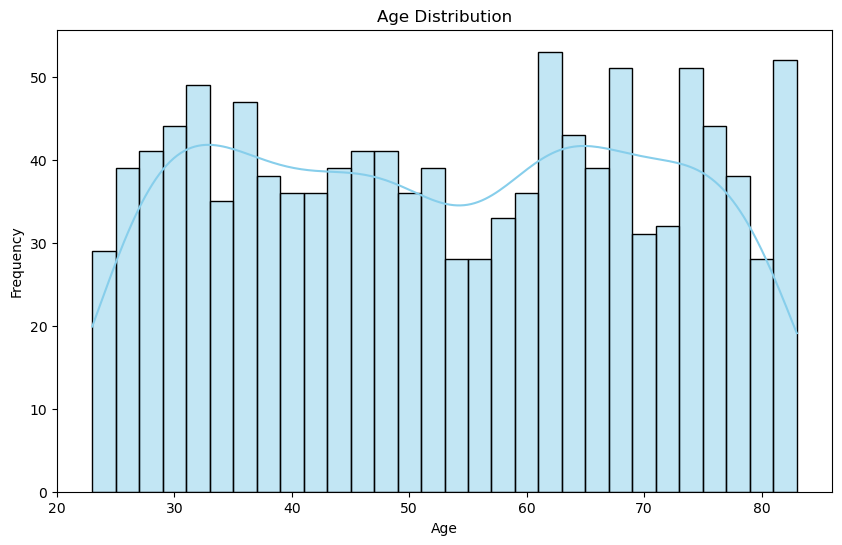

```python
# Age distribution based on DOB
employee_data['DOB'] = pd.to_datetime(employee_data['DOB'], errors='coerce')
employee_data['Age'] = pd.Timestamp.now().year - employee_data['DOB'].dt.year

plt.figure(figsize=(10, 6))
sns.histplot(employee_data['Age'], kde=True, bins=30, color='skyblue')
plt.title("Age Distribution")
plt.xlabel("Age")
plt.ylabel("Frequency")
plt.show()
```

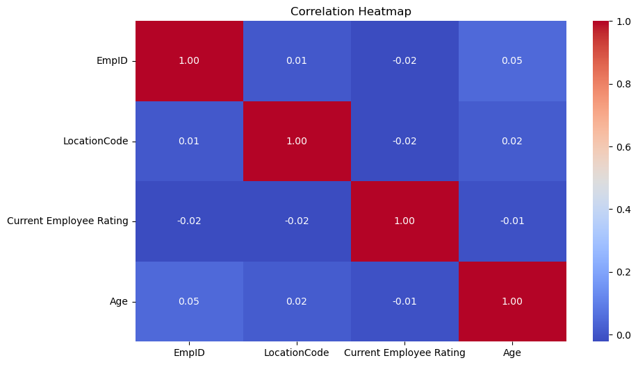

```python
# Correlation heatmap for numeric columns
numeric_cols = employee_data.select_dtypes(include=['int64', 'float64'])
plt.figure(figsize=(10, 6))
sns.heatmap(numeric_cols.corr(), annot=True, cmap='coolwarm', fmt=".2f")
plt.title("Correlation Heatmap")
plt.show()
```

## Findings:

1. **Minimal Correlation**:
   - There is little to no correlation between `Current Employee Rating` and other features such as `Age`, `LocationCode`, and `EmpID`. The strongest correlation observed is 0.05 between `EmpID` and `Age`, which is still weak.
2. **Independence of Variables**:
   - Most variables in the dataset are largely independent of one another, indicating they might not directly influence each other.

## Insights:

1. **Predictive Modeling Implication**:
   - The lack of strong correlations suggests that a multivariate analysis or feature engineering might be required to uncover latent relationships if these variables are used in predictive modeling.
2. **Focus on Other Features**:
   - Since `Current Employee Rating` shows no meaningful correlation with variables like `Age` or `LocationCode`, other variables should be explored to explain or predict employee ratings effectively.

### Handling Missing Data

```python
# Handling missing values

# Fill missing 'ExitDate' with 'Not Applicable' for active employees
employee_data['ExitDate'].fillna('Not Applicable', inplace=True)

# Fill missing 'TerminationDescription' with 'Not Applicable' for active employees
employee_data['TerminationDescription'].fillna('Not Applicable', inplace=True)

# Confirm there are no missing values left
missing_values_after = employee_data.isnull().sum()
```

[output not shown]

```python
# Handling missing values in 'DOB'
# For simplicity, we'll fill missing 'DOB' with the median DOB of non-missing values
median_dob = employee_data['DOB'].median()
employee_data['DOB'].fillna(median_dob, inplace=True)

# Recalculate 'Age' after filling missing 'DOB'
employee_data['Age'] = pd.Timestamp.now().year - employee_data['DOB'].dt.year
```

```python
print("Missing Values After Handling:\n", missing_values_after)
```

```python
employee_data['Retention'] = employee_data['ExitDate'] == 'Not Applicable'

# Grouping by factors of interest and calculating retention rates
factors = ['BusinessUnit', 'GenderCode','RaceDesc',  'Performance Score']
retention_analysis = {}

for factor in factors:
    retention_analysis[factor] = (
        employee_data.groupby(factor)['Retention']
        .mean()
        .sort_values(ascending=False)
        .reset_index()
    )
```

### Retention Rates by Business Unit

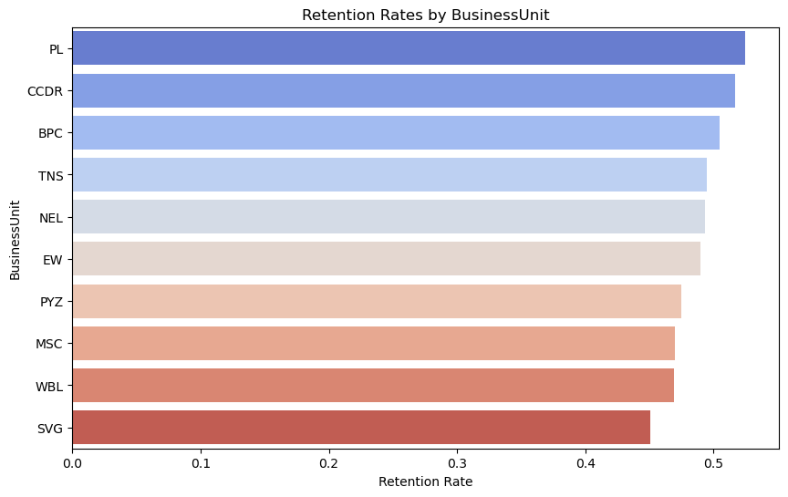

```python
plt.figure(figsize=(10, 6))
sns.barplot(data=retention_analysis['BusinessUnit'], x='Retention', y='BusinessUnit', palette='coolwarm')
plt.title("Retention Rates by BusinessUnit")
plt.xlabel("Retention Rate")
plt.ylabel("BusinessUnit")
plt.show()
```

### Findings:

1. Business units such as `PL` and `CCDR` have higher retention rates (~52%).
2. Units like `SVG` and `WBL` exhibit lower retention rates (~45%).

### Insights:

1. Business units with specialized operations or fewer external influences (e.g., `PL`) tend to retain employees better.
2. Units with lower retention could benefit from targeted engagement programs to address employee concerns.

### **Retention Rates by Performance Score**

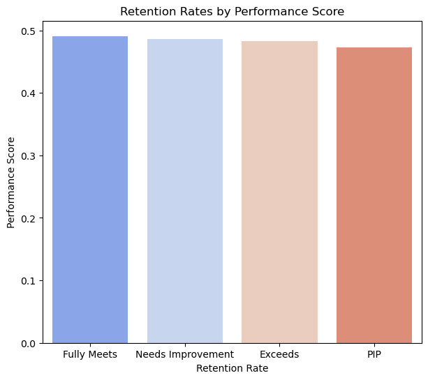

```python
plt.figure(figsize=(7, 6))
sns.barplot(data=retention_analysis['Performance Score'], x='Performance Score', y='Retention', palette='coolwarm')
plt.title("Retention Rates by Performance Score")
plt.xlabel("Retention Rate")
plt.ylabel("Performance Score")
plt.show()
```

### Findings:

1. Employees with "Fully Meets" and "Needs Improvement" scores have slightly higher retention (~49%).
2. Those on "PIP" (Performance Improvement Plan) have lower retention (~47%).

## **Retention Rates by Gender**

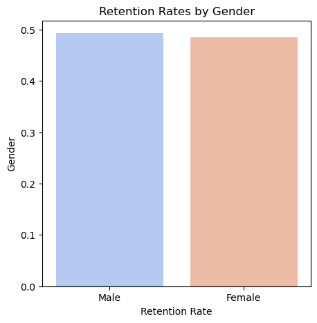

```python
plt.figure(figsize=(5, 5))
sns.barplot(data=retention_analysis['GenderCode'], x='GenderCode', y='Retention', palette='coolwarm')
plt.title("Retention Rates by Gender")
plt.xlabel("Retention Rate")
plt.ylabel("Gender")
plt.show()
```

### Findings:

1. Male employees have a slightly higher retention rate (~ 49.3%) compared to females (~48.6%).
2. The difference in retention between genders is minimal.

### Insights:

1. Gender retention parity reflects positive organizational inclusivity practices.
2. Any observed retention gaps could be mitigated by analyzing department-specific gender dynamics.

## **Retention Rates by Race**

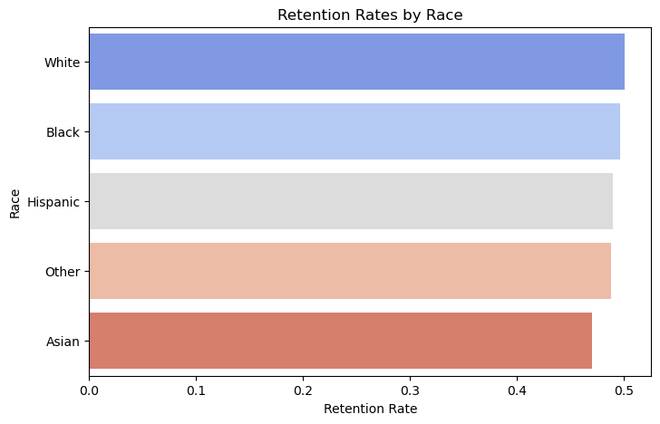

```python
plt.figure(figsize=(8, 5))
sns.barplot(data=retention_analysis['RaceDesc'], x='Retention', y='RaceDesc', palette='coolwarm')
plt.title("Retention Rates by Race")
plt.xlabel("Retention Rate")
plt.ylabel("Race")
plt.show()
```

### Findings:

1. White employees show the highest retention (~ 50%), while Asians have the lowest (~47%).
2. Hispanic, Black, and Other races have similar retention rates (~48%-49%).

### Insights:

1. Higher retention for White employees may suggest better alignment with workplace practices or benefits.
2. Retention disparities could be addressed by fostering cultural inclusivity and representation in leadership roles.

```python
# Analysis of "Current Employee Rating" across Job Titles, Departments, and Business Units

# Factors of interest
rating_factors = ['Title', 'DepartmentType', 'BusinessUnit']
rating_analysis = {}

for factor in rating_factors:
    # Grouping by the factor and calculating the mean rating
    rating_analysis[factor] = (
        employee_data.groupby(factor)['Current Employee Rating']
        .mean()
        .sort_values(ascending=False)
        .reset_index()
    )
```

## Average Employee Rating by Job Title

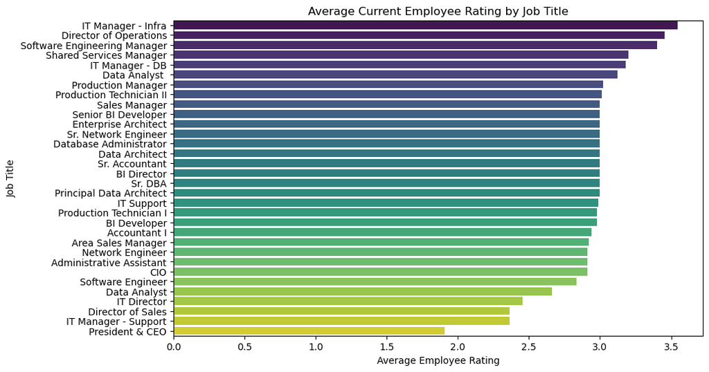

```python
plt.figure(figsize=(10, 6))
sns.barplot(
    data=rating_analysis['Title'],
    x='Current Employee Rating',
    y='Title',
    palette='viridis'
)
plt.title("Average Current Employee Rating by Job Title")
plt.xlabel("Average Employee Rating")
plt.ylabel("Job Title")
plt.show()
```

### Findings:

1. The highest ratings are for `IT Manager - Infra` (3.55), `Director of Operations` (3.45), and `Software Engineering Manager` (3.40).
2. The lowest ratings are for `President & CEO` (1.91), `IT Manager - Support` (2.36), and `Director of Sales` (2.36).

### Insights:

1. Leadership roles like `IT Manager - Infra` and `Director of Operations` have higher satisfaction, indicating strong alignment with their job responsibilities.
2. Lower ratings for executive-level positions like `President & CEO` suggest potential dissatisfaction or higher stress levels in top management roles.

## Average Employee Rating by Department Type

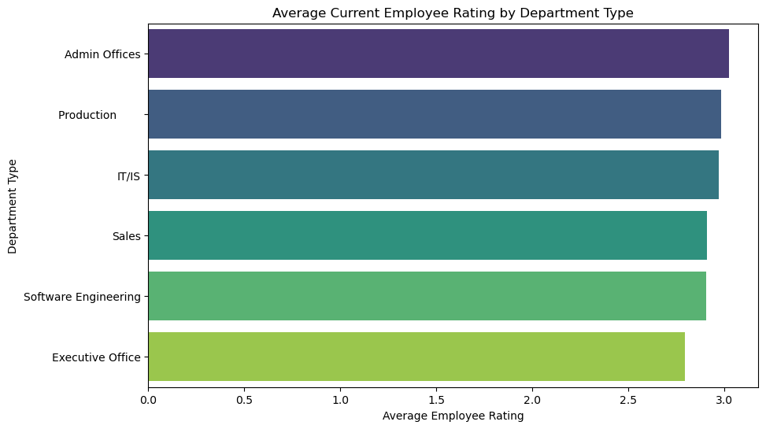

```python
plt.figure(figsize=(10, 6))
sns.barplot(
    data=rating_analysis['DepartmentType'],
    x='Current Employee Rating',
    y='DepartmentType',
    palette='viridis'
)
plt.title("Average Current Employee Rating by Department Type")
plt.xlabel("Average Employee Rating")
plt.ylabel("Department Type")
plt.show()
```

### Findings:

1. The `Admin Offices` department has the highest average rating (3.03), followed by `Production` (2.98).
2. The lowest ratings are in `Executive Office` (2.79) and `Software Engineering` (2.90).

### Insights:

1. Employees in administrative and production departments may experience more structured and predictable workflows, leading to higher satisfaction.
2. Lower ratings in executive and software engineering departments could point to challenges like demanding workloads or lack of clear progression opportunities.

### Analysis of termination types and reasons across business units

```python
# Grouping by TerminationType and TerminationDescription
termination_counts = (
    employee_data.groupby(['TerminationType', 'TerminationDescription'])
    .size()
    .sort_values(ascending=False)
    .reset_index(name='Count')
)

# Grouping by BusinessUnit and TerminationType
termination_business_unit = (
    employee_data.groupby(['BusinessUnit', 'TerminationType'])
    .size()
    .unstack(fill_value=0)
    .reset_index()
)

# Grouping by JobFunctionDescription and TerminationType
termination_job_function = (
    employee_data.groupby(['JobFunctionDescription', 'TerminationType'])
    .size()
    .unstack(fill_value=0)
    .reset_index()
)

# Display the top termination types and reasons
print("\nMost Common Termination Types and Reasons:\n", termination_counts.head(10))
```

```
Most Common Termination Types and Reasons:
   TerminationType                           TerminationDescription  Count
0             Unk                                   Not Applicable   1467
1     Involuntary                             A especially friend.      1
2      Retirement                      Power picture early anyone.      1
3      Retirement                    Prove do voice ten likely do.      1
4      Retirement                  Professor anyone example never.      1
5      Retirement                           Production senior put.      1
6      Retirement     Produce seek result he political alone form.      1
7      Retirement            Process firm life from final medical.      1
8      Retirement  Price card crime. Beautiful travel world treat.      1
9      Retirement                   Pretty line two she accept be.      1
```

### Termination Types Across Business Units

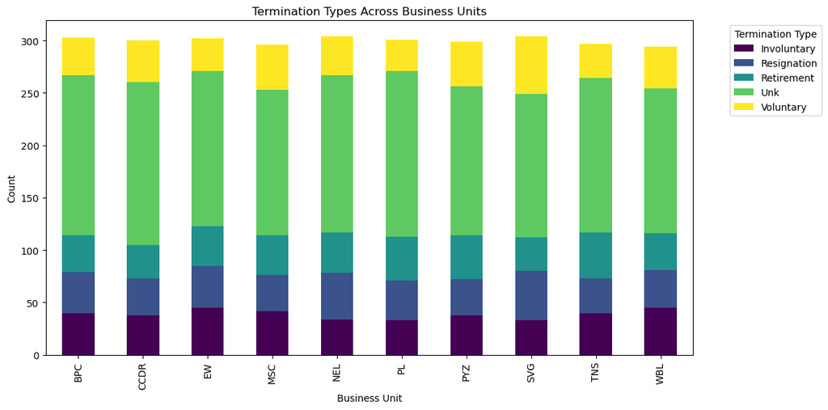

```python
# Visualization of termination types across business units
termination_business_unit.set_index('BusinessUnit').plot(kind='bar', stacked=True, figsize=(12, 6), colormap='viridis')
plt.title("Termination Types Across Business Units")
plt.xlabel("Business Unit")
plt.ylabel("Count")
plt.legend(title="Termination Type", bbox_to_anchor=(1.05, 1))
plt.tight_layout()
plt.show()
```